# Mendeley

From Wikipedia, the free encyclopedia

[output not shown]

Mendeley Desktop

[figure not shown]

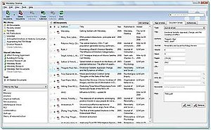

Mendeley Desktop

[Original author(s)](https://en.wikipedia.org/wiki/Programmer)

Paul Foeckler, Victor Henning, Jan Reichelt<sup>[1]</sup>

[Developer(s)](https://en.wikipedia.org/wiki/Programmer)

Elsevier

Initial release

August 2008

[Stable release](https://en.wikipedia.org/wiki/Software_release_life_cycle)

1.19.5 / 2019

Available in

English

[Type](https://en.wikipedia.org/wiki/Software_categories#Categorization_approaches)

[Reference management software](https://en.wikipedia.org/wiki/Reference_management_software)

[License](https://en.wikipedia.org/wiki/Software_license)

[Proprietary](https://en.wikipedia.org/wiki/Proprietary_software)

Website

[mendeley.com](http://mendeley.com/)

**Mendeley** is a software company based in London, UK, which provides products and services for academic researchers. It is most known for its [reference manager](https://en.wikipedia.org/wiki/Reference_management) which is used to manage and share research papers<sup>[2]</sup> and generate [bibliographies](https://en.wikipedia.org/wiki/Bibliography) for scholarly articles.

## History[[edit](https://en.wikipedia.org/w/index.php?title=Mendeley&action=edit&section=1)]

Mendeley, named after the biologist [Gregor Mendel](https://en.wikipedia.org/wiki/Gregor_Mendel) and chemist [Dmitri Mendeleev](https://en.wikipedia.org/wiki/Dmitri_Mendeleev),<sup>[3]</sup> was founded in London in November 2007 by three German [PhD](https://en.wikipedia.org/wiki/Doctor_of_Philosophy) students. The first public [beta version](https://en.wikipedia.org/wiki/Beta_version) of the software was released in August 2008. The company's investors included some people previously involved with Last.fm, Skype, and [Warner Music Group](https://en.wikipedia.org/wiki/Warner_Music_Group),<sup>[4]</sup> as well as academicians from [Cambridge](https://en.wikipedia.org/wiki/Cambridge_University) and [Johns Hopkins University](https://en.wikipedia.org/wiki/Johns_Hopkins_University).

### Early success[[edit](https://en.wikipedia.org/w/index.php?title=Mendeley&action=edit&section=2)]

[figure not shown]

Victor Henning and Jan Reichelt receiving the Plugg "European Start-up of the Year" award, 2009

Mendeley won several awards in 2009 including Plugg.eu "European Start-up of the Year 2009",<sup>[5]</sup><sup>[6]</sup> TechCrunch Europas "Best Social Innovation Which Benefits Society 2009",<sup>[7]</sup> and [The Guardian](https://en.wikipedia.org/wiki/The_Guardian) ranked it #6 in "Top 100 tech media companies".<sup>[8]</sup>

In 2012, Mendeley was one of the [repositories](https://en.wikipedia.org/wiki/Open_access_repository) for [green Open Access](https://en.wikipedia.org/wiki/Green_Open_Access) recommended by [Peter Suber](https://en.wikipedia.org/wiki/Peter_Suber).<sup>[9]</sup> The recommendation was revoked after Elsevier bought Mendeley.<sup>[10]</sup>

### Purchase by Elsevier[[edit](https://en.wikipedia.org/w/index.php?title=Mendeley&action=edit&section=3)]

David Dobbs, in *[The New Yorker](https://en.wikipedia.org/wiki/The_New_Yorker)*, suggested Elsevier's reasons for buying Mendeley could have been to acquire its user data and/or to "destroy or coopt an open-science icon that threatens its business model."<sup>[14]</sup> This was contrasted to a non-profit service like Unpaywall, which marketed itself as not susceptible to a sell-out to Elsevier.<sup>[15]</sup>

### Extensions to product line[[edit](https://en.wikipedia.org/w/index.php?title=Mendeley&action=edit&section=4)]

After acquisition, Mendeley subsequently extended its product line into new areas while continuing to iterate on its reference manager.

On 23 September 2013, Mendeley announced [iPhone](https://en.wikipedia.org/wiki/IPhone) and [iPad](https://en.wikipedia.org/wiki/IPad) apps.<sup>[16]</sup> An Android app followed shortly after.

On 12 January 2015, Mendeley announced the acquisition of Newsflo, a service which provided links to press coverage of researchers' work.<sup>[17]</sup><sup>[18]</sup> The functionality was subsequently incorporated into Mendeley Feed and Mendeley Profile.

In April 2016, Mendeley Data, a platform for sharing citable research datasets online, was promoted out of beta.<sup>[19]</sup>

In October 2016, Mendeley Careers was launched to help researchers locate job opportunities.<sup>[20]</sup>

On 24 May 2019, Mendeley announced two new products: Mendeley Reference Manager and Mendeley Cite.<sup>[21]</sup>

On March 15, 2021 the Mendeley mobile app is being removed from the Apple App Store and Google Play, leaving access via the web site or Mendeley Reference Manager on the desktop.<sup>[22]</sup> The literature search function in the desktop application has also been removed.

## Products[[edit](https://en.wikipedia.org/w/index.php?title=Mendeley&action=edit&section=5)]

Mendeley is [freemium](https://en.wikipedia.org/wiki/Freemium) software.

- Mendeley Desktop, the original reference manager based on the Qt framework that runs on [Microsoft Windows](https://en.wikipedia.org/wiki/Microsoft_Windows), [macOS](https://en.wikipedia.org/wiki/MacOS), and Linux
- Mendeley Reference Manager (Beta), a replacement reference manager built with Electron that also runs on Microsoft Windows, Mac, Linux, and all major web browsers
- Mendeley Web Importer, a [browser extension](https://en.wikipedia.org/wiki/Browser_extension) that imports metadata and retrieves legal full text scholarly articles discovered on the Web
- Mendeley Cite, an add-in for [Microsoft Word](https://en.wikipedia.org/wiki/Microsoft_Word) for citing references and generating bibliographies
- Mendeley mobile apps for reading articles on the go, available for [iOS](https://en.wikipedia.org/wiki/IOS) and Android. These are being removed on March 15, 2021.<sup>[22]</sup>
- Mendeley Profile, a public showcase for research outputs and receiving citation and usage statistics on one's personal research output
- Mendeley Catalog, a crowd-sourced index of scholarly articles with over 90 million unique records
- Mendeley Feed, a timeline of new publications from the Mendeley profiles of followed researchers and their mentions in the media
- Mendeley Suggest, email recommendations of new articles to read based on use within Mendeley
- Mendeley Data, a free [research data management](https://en.wikipedia.org/wiki/Research_data_archiving) solution
- Mendeley Careers, a job listings and CV hosting site for researchers
- Mendeley Funding, a search portal for research funding opportunities
- Mendeley Institutional Edition, enabling institutional administrators to gain analytical insights into their researchers' use of journals while upgrading reference manager storage and group collaborator limits <sup>[23]</sup>
- Mendeley Developer Portal, which offers open [APIs](https://en.wikipedia.org/wiki/API) for interacting with the reference manager programmatically

## Notable features[[edit](https://en.wikipedia.org/w/index.php?title=Mendeley&action=edit&section=6)]

- Mendeley reader counts, a unique readership statistic which has been asserted to predict citation impact <sup>[24]</sup>
- Automatic extraction of metadata from PDF articles
- Claim authored publications by linking the user's Mendeley Profile to Scopus Author Profile
- Citations and bibliographies in [Microsoft Word](https://en.wikipedia.org/wiki/Microsoft_Word), OpenOffice.org, and LibreOffice
- Private groups to share and annotate research papers within copyright-compliant responsible sharing guidelines

## Incidents[[edit](https://en.wikipedia.org/w/index.php?title=Mendeley&action=edit&section=7)]

In 2018, an update to Mendeley resulted in some users losing PDFs and annotations stored in their accounts.<sup>[25]</sup> Elsevier fixed the issue for most users after a number of weeks.<sup>[26]</sup>

## See also[[edit](https://en.wikipedia.org/w/index.php?title=Mendeley&action=edit&section=8)]

- [Comparison of reference management software](https://en.wikipedia.org/wiki/Comparison_of_reference_management_software)
- [Metadata discovery](https://en.wikipedia.org/wiki/Metadata_discovery)
- [Citation Style Language](https://en.wikipedia.org/wiki/Citation_Style_Language)
- [List of academic databases and search engines](https://en.wikipedia.org/wiki/List_of_academic_databases_and_search_engines)

## Notes and references[[edit](https://en.wikipedia.org/w/index.php?title=Mendeley&action=edit&section=9)]

1. **^** Elsevier (24 July 2013). ["Victor Henning's brief guide to Mendeley"](https://www.elsevier.com/connect/victor-hennings-brief-guide-to-mendeley). *Elsevier Connect*. Retrieved 2 July 2019.
2. **^** Jason Fitzpatrick (2009-08-17). ["Mendeley Manages Your Documents on Your Desktop and in the Cloud"](https://lifehacker.com/5334254/mendeley-manages-your-documents-on-your-desktop-and-in-the-cloud). Retrieved 2009-08-17.
3. **^** Victor Henning, [How our name evolved from B-movie monster to Mendeley](http://blog.mendeley.com/start-up-life/how-our-name-evolved-from-b-movie-monster-to-mendeley/), 23 April 2008
4. **^** ["Case study – Mendeley shares scientific research to build a better future"](https://www.gov.uk/government/case-studies/mendeley-shares-scientific-research-to-build-a-better-future). *www.gov.uk*. 1 August 2014. Retrieved 2017-12-29.
5. **^** Plugg.eu (2009-03-12). ["Winners for Plugg Start-Ups Rally 2009 announced"](https://web.archive.org/web/20090318234932/http://plugg.eu/media/blog/p/detail/winners-for-plugg-start-ups-rally-2009-announced). Archived from the original on 2009-03-18. Retrieved 2009-03-25.: CS1 maint: bot: original URL status unknown ()
6. **^** TechCrunch (2009-03-12). ["Plugg wraps with two very capable winners"](https://techcrunch.com/2009/03/12/plugg-wraps-with-two-very-capable-winnners/). Retrieved 2009-03-25.
7. **^** TechCrunch (2009-07-09). ["The Europas: The Winners and Finalists"](https://techcrunch.com/2009/07/09/the-europas-the-winners-and-finalists/).
8. **^** The Guardian (2009-09-07). ["The top 100 tech media companies"](https://www.theguardian.com/tech-media-invest-100/top-100). London.
9. **^** Suber, Peter (2012). *Open Access*. MIT Press Essential Knowledge. Cambridge, Massachusetts: The MIT Press. ISBN 978-0-262-51763-8.
10. **^** Peter Suber (2013-04-09). ["Elsevier bought Mendeley"](https://plus.google.com/+PeterSuber/posts/e4iZMQfoENc).
11. **^** [Confirmed: Elsevier Has Bought Mendeley For $69M-$100M To Expand Its Open, Social Education Data Efforts](https://techcrunch.com/2013/04/08/confirmed-elsevier-has-bought-mendeley-for-69m-100m-to-expand-open-social-education-data-efforts/). 8 April 2013.
12. **^** [*Elsevier takes over Mendeley: And you, what do you think?*](http://www.mysciencework.com/en/MyScienceNews/9916/elsevier-takes-over-mendeley-and-you-what-do-you-think)*,* [MyScienceWork](http://www.mysciencework.com/en/) [Archived](https://web.archive.org/web/20130524065302/http://www.mysciencework.com/en/) 2013-05-24 at the [Wayback Machine](https://en.wikipedia.org/wiki/Wayback_Machine)
13. **^** ["The Empire acquires the rebel alliance: Mendeley users revolt against Elsevier takeover"](http://paidcontent.org/2013/04/09/the-empire-acquires-the-rebel-alliance-mendeley-users-revolt-against-elsevier-takeover/). paidContent. Apr 9, 2013. Retrieved 13 March 2014.
14. ^ Jump up to: <sup>**a**</sup> <sup>**b**</sup> ["When the Rebel Alliance Sells Out"](http://www.newyorker.com/online/blogs/elements/2013/04/elsevier-mendeley-journals-science-software.html), David Dobbs, *[The New Yorker](https://en.wikipedia.org/wiki/The_New_Yorker)*, April 12, 2013
15. **^** ["Unpaywall: a beautiful way to help everyone Get The Research"](https://blogs.lse.ac.uk/impactofsocialsciences/2018/10/28/unpaywall-a-beautiful-way-to-help-everyone-get-the-research/). 2018-10-28. Retrieved 2020-04-25.
16. **^** stevedennis (2013-09-23). ["The New Mendeley for iPad and iPhone"](https://blog.mendeley.com/2013/09/23/the-new-mendeley-for-ipad-and-iphone/). *Mendeley Blog*. Retrieved 2019-08-29.
17. **^** Bonasio, Alice (2015-01-12). ["Newsflo brings new impact metrics to Mendeley"](https://blog.mendeley.com/2015/01/12/newsflo-brings-new-impact-metrics-to-mendeley/). *Mendeley Blog*. Retrieved 2019-08-29.
18. **^** ["Elsevier Acquires Media Monitoring Company Newsflo"](https://www.elsevier.com/about/press-releases/corporate/elsevier-acquires-media-monitoring-company-newsflo). *www.elsevier.com*. Retrieved 2019-08-29.
19. **^** Josh (2016-04-28). ["Mendeley Data is out of beta"](https://blog.mendeley.com/2016/04/28/mendeley-data-is-out-of-beta/). *Mendeley Blog*. Retrieved 2019-08-29.
20. **^** Desai, Shruti (2016-09-30). ["Search thousands of science and technology jobs at Mendeley Careers – launching in October"](https://blog.mendeley.com/2016/09/30/search-thousands-of-science-and-technology-jobs-at-mendeley-careers-launching-in-october/). *Mendeley Blog*. Retrieved 2019-08-29.
21. **^** sallyransom (2019-05-24). ["Supporting researchers with the new Mendeley Reference Manager"](https://blog.mendeley.com/2019/05/24/supporting-researchers-with-the-new-mendeley-reference-manager/). *Mendeley Blog*. Retrieved 2019-08-29.
22. ^ Jump up to: <sup>**a**</sup> <sup>**b**</sup> ["Accessing your Mendeley library after the mobile app is no longer available"](https://service.elsevier.com/app/answers/detail/a_id/33378/supporthub/mendeley/p/16075/). *Mendeley Support Center*.
23. **^** ["Mendeley Manual for Librarians"](https://www.elsevier.com/__data/assets/pdf_file/0011/117992/Mendeley-Manual-for-Librarians_2017.pdf) (PDF). Retrieved 2019-08-29.
24. **^** Thelwall, Mike (2018-06-01). "Early Mendeley readers correlate with later citation counts". *Scientometrics*. **115** (3): 1231–1240. doi:[10.1007/s11192-018-2715-9](https://doi.org/10.1007%2Fs11192-018-2715-9). hdl:[2436/621193](https://hdl.handle.net/2436%2F621193). ISSN 1588-2861. S2CID 4352809.
25. **^** ["Thousands of researchers hit by Mendeley update glitch"](https://www.timeshighereducation.com/news/thousands-researchers-hit-mendeley-update-glitch). *Times Higher Education (THE)*. 2018-06-15. Retrieved 2018-07-04.
26. **^** ["Update on the missing PDF issue"](https://blog.mendeley.com/2018/06/27/update-on-the-missing-pdf-issue/). *Mendeley Blog*. 2018-06-27. Retrieved 2018-07-04.

## External links[[edit](https://en.wikipedia.org/w/index.php?title=Mendeley&action=edit&section=10)]

- [Official website](http://www.mendeley.com/)

[Categories](https://en.wikipedia.org/wiki/Help:Category):

- [Reference management software](https://en.wikipedia.org/wiki/Category:Reference_management_software)
- [Software that uses Qt](https://en.wikipedia.org/wiki/Category:Software_that_uses_Qt)
- [Windows software](https://en.wikipedia.org/wiki/Category:Windows_software)
- [2013 mergers and acquisitions](https://en.wikipedia.org/wiki/Category:2013_mergers_and_acquisitions)
- RELX